# jrieksta_231019 slides

### **Model comparison (NorESM2-LM vs UKESM1-0-LL)**

#### **Group 1** (Sara)

##### Jolanta Rieksta (University of Copenhagen)

### **Introduction**

###### **BVOC** essentials inputs in the models

###### **Importance of Isoprene:** most emitted BVOC; atmospheric oxidation; ozone; and SOA

#### This study aims to investigate the effects of using different LM (NorESM and UKESM) (Guenther et al 2012 and Arneth et al) and test their performance in simulating isoprene emissions and organic aerosols.

[output not shown]

### **Methods**

#### -Data arrangements

##### -*pyaerocom* to collocate the data and obtain the model evaluation statistics

##### - Look at the seasonal variation in each model compare the absolute difference between models

##### - Obtain the absolute model difference in %

##### - Obtain the mean across all years (1980-2014)

##### - Compare emission rates of isoprene to organic aerosols between the models

##### - Compare the isoprene concentrations of observed data to model data

## Results

## Seasonal variation NorESM vs UKESM

```
['DJF' 'JJA' 'MAM' 'SON']
```

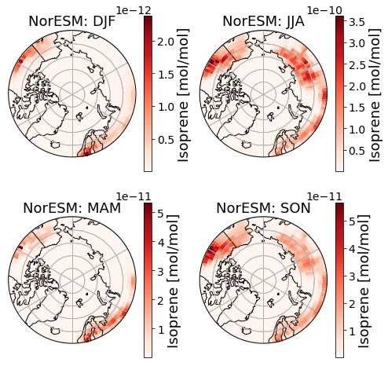

```
['DJF' 'JJA' 'MAM' 'SON']
```

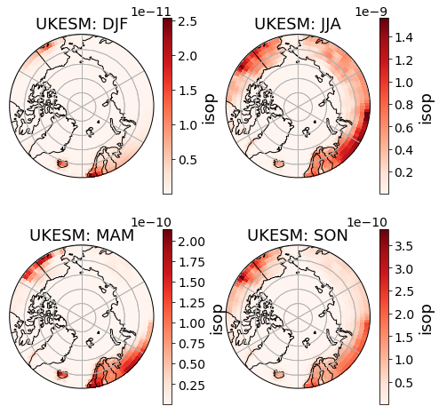

## Difference NorESM vs UKESM

```
['DJF' 'JJA' 'MAM' 'SON']
```

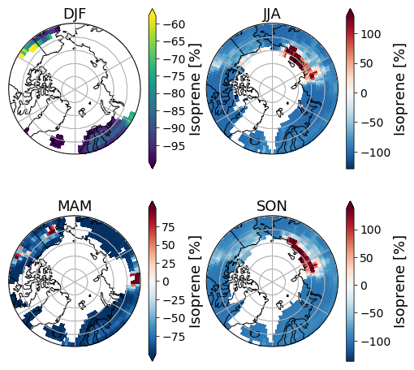

### NorESM vs UKESM (*pyaerocom*)

[figure not shown]

## OA vs Isoprene concentrations

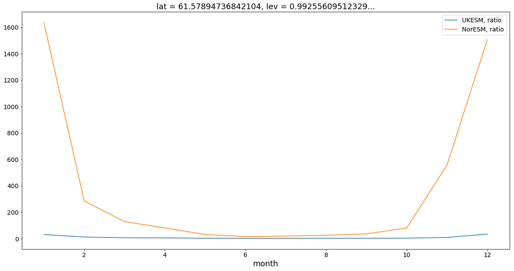

```
found station name: Birkenes II
Returning (<station name>, <lon>, <lat>)
('Birkenes II', 8.252, 58.38853)
found station name: Zeppelin mountain (Ny-Ålesund)
Returning (<station name>, <lon>, <lat>)
('Zeppelin mountain (Ny-Ålesund)', 11.88668, 78.90715)
```

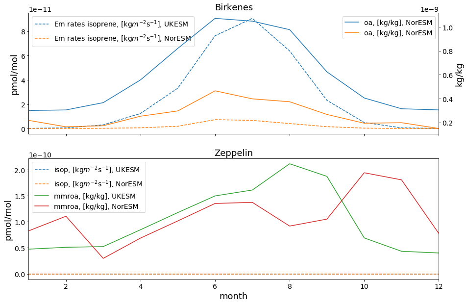

|  | Isoprene [mol/mol] | Organic aerosol [kg/kg] |
| --- | --- | --- |
| NorESM | 7.81929e-12 | 2.98425e-10 |
| UKESM | 1.13134e-10 | 4.93936e-10 |
| UKESM-NorESM % | 1346.86 | 65.514 |

```
found station name: Birkenes II
Returning (<station name>, <lon>, <lat>)
('Birkenes II', 8.252, 58.38853)
found station name: Zeppelin mountain (Ny-Ålesund)
Returning (<station name>, <lon>, <lat>)
('Zeppelin mountain (Ny-Ålesund)', 11.88668, 78.90715)
```

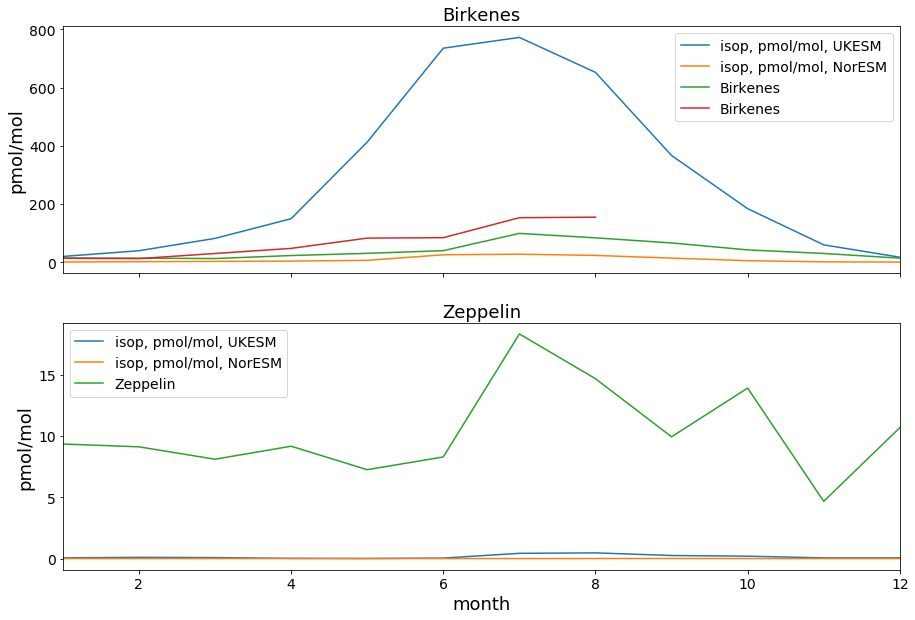

### Conclusions and to do's

##### -NorESM and UKESM use emission schemes, that results in substantial difference in Isoprene emissions, concentrations and OA

##### -Overall NorESM has lower emissions and OA compare to UKESM

##### -Overall NorESM has lower emissions and OA compare to UKESM

##### -Station data: UKESM overstimating the emissions; Zeppelin station have substantially higher emissions comapre to the models

##### -UKESM has less aerosols per isoprene, compare NORESM

##### -There are differences in seasonal variation in emissions and OA

##### -NorESM might have anoter source of OA

##### -Observation data from Hyytiälä

##### -OA observation data from EBAS

##### -Maybe incorporate our Isoprene data

### References and Acknowledgments

###### -Jiang, Jianhui, Sebnem Aksoyoglu, Giancarlo Ciarelli, Emmanouil Oikonomakis, Imad El-Haddad, Francesco Canonaco, Colin O'Dowd et al. "Effects of two different biogenic emission models on modelled ozone and aerosol concentrations in Europe." Atmospheric Chemistry and Physics 19, no. 6 (2019): 3747-3768.

###### -Sporre, Moa K., Sara M. Blichner, Inger HH Karset, Risto Makkonen, and Terje K. Berntsen. "BVOC–aerosol–climate feedbacks investigated using NorESM." Atmospheric Chemistry and Physics 19, no. 7 (2019): 4763-4782.

###### -Guenther, A. B., Xiaoyan Jiang, C. L. Heald, T. Sakulyanontvittaya, Tiffany Duhl, L. K. Emmons, and X. Wang. "The Model of Emissions of Gases and Aerosols from Nature version 2.1 (MEGAN2. 1): an extended and updated framework for modeling biogenic emissions." Geoscientific Model Development 5, no. 6 (2012): 1471-1492.

##### CMIP6

##### EBAS

##### pyaerocom

##### SARA <3